# American Beliefs

Renato Silva

2026-06-04

```r
library(tidyverse)
library(readr)
setwd("D:/American-Beliefs-Renato-Silva/Data")

df <- read.csv("data-TRrb5.csv", stringsAsFactors = FALSE)

names(df)[1] <- "Category"

headers <- c(
  "Religion",
  "Religious service attendance",
  "Political party",
  "Income",
  "Age",
  "Gender",
  "Education"
)

data <- df %>%
  filter(!Category %in% headers)

# Convert percentages to numeric
belief_cols <- c("God", "Angels", "Heaven", "Hell", "The.devil")

data[belief_cols] <- lapply(
  data[belief_cols],
  function(x) as.numeric(gsub("%", "", x))
)
unique(data$Category)
```

```
##  [1] "Weekly"                     "Nearly Weekly/Monthly"
##  [3] "Less often"                 "Protestant/Other Christian"
##  [5] "Catholic"                   "None"
##  [7] "Party identification"       "Republican"
##  [9] "Independent"                "Democrat"
## [11] "Annual household income"    "Less than $40,000"
## [13] "$40,000-100,000"            "$100,000+"
## [15] "Age "                       "55 and older"
## [17] "35-54"                      "18-34"
## [19] "Female"                     "Male"
## [21] "Not college grad"           "College grad"
```

```r
# Summary Statistics

summary(data[belief_cols])
```

```
##       God            Angels          Heaven           Hell
##  Min.   :25.00   Min.   :25.00   Min.   :17.00   Min.   :15.00
##  1st Qu.:68.00   1st Qu.:60.50   1st Qu.:59.50   1st Qu.:51.50
##  Median :73.00   Median :68.00   Median :66.00   Median :58.00
##  Mean   :73.89   Mean   :69.68   Mean   :67.05   Mean   :59.11
##  3rd Qu.:84.00   3rd Qu.:82.50   3rd Qu.:76.00   3rd Qu.:64.50
##  Max.   :98.00   Max.   :94.00   Max.   :92.00   Max.   :84.00
##  NA's   :3       NA's   :3       NA's   :3       NA's   :3
##    The.devil
##  Min.   :12.00
##  1st Qu.:51.00
##  Median :58.00
##  Mean   :57.95
##  3rd Qu.:63.00
##  Max.   :86.00
##  NA's   :3
```

```r
sapply(data[belief_cols], mean)
```

```
##       God    Angels    Heaven      Hell The.devil
##        NA        NA        NA        NA        NA
```

```r
sapply(data[belief_cols], median)
```

```
##       God    Angels    Heaven      Hell The.devil
##        NA        NA        NA        NA        NA
```

```r
sapply(data[belief_cols], sd)
```

```
##       God    Angels    Heaven      Hell The.devil
##        NA        NA        NA        NA        NA
```

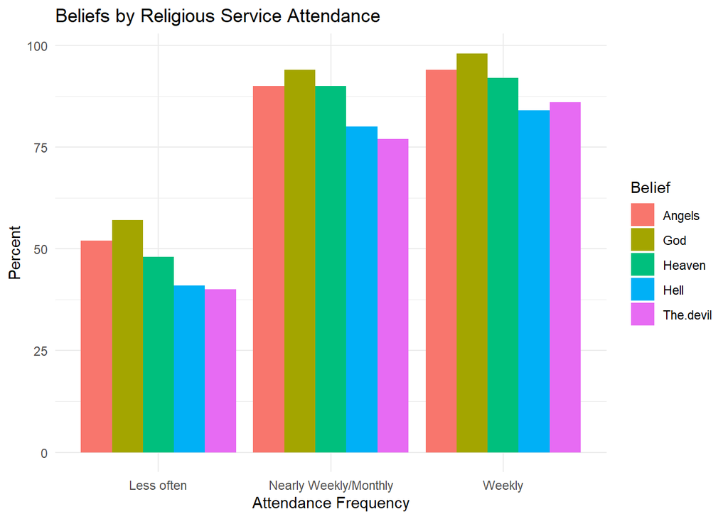

```r
# Visualization 1: Religious Service Attendance

attendance <- data %>%
  filter(Category %in% c(
    "Weekly",
    "Nearly Weekly/Monthly",
    "Less often"
  ))

attendance_long <- attendance %>%
  pivot_longer(
    cols = all_of(belief_cols),
    names_to = "Belief",
    values_to = "Percent"
  )

ggplot(attendance_long,
       aes(x = Category,
           y = Percent,
           fill = Belief)) +
  geom_bar(stat = "identity",
           position = "dodge") +
  labs(
    title = "Beliefs by Religious Service Attendance",
    x = "Attendance Frequency",
    y = "Percent"
  ) +
  theme_minimal()
```

This is to be expected those that tend to go more often to their religious services be it mass or congregation, they are more likely to hold beliefs in line with their religion and they arent “lukewarm” believers, but the difference between those who go weekly and monthly is not much which is surprising but then again in today’s day and age there is seldom much time to go or the energy to go sadly. I also struggle with having the time and energy despite knowing I have an obligation to go, I try to do my best.

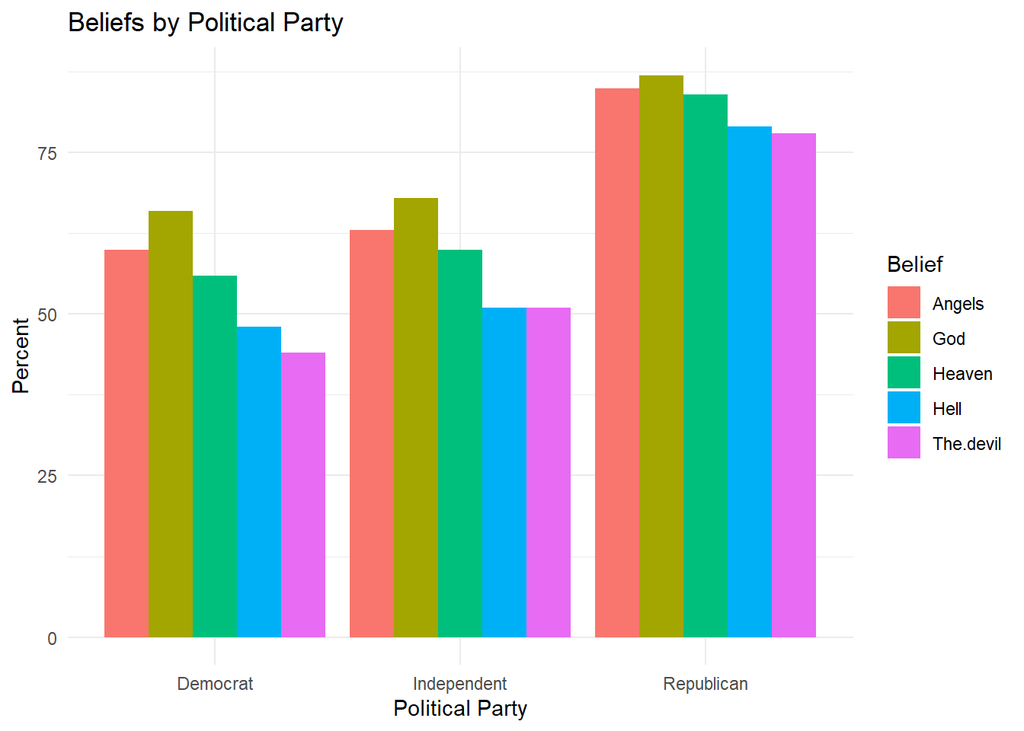

```r
# Visualization 2:Political Party

party <- data %>%
  filter(Category %in% c(
    "Republican",
    "Democrat",
    "Independent"
  ))

party_long <- party %>%
  pivot_longer(
    cols = all_of(belief_cols),
    names_to = "Belief",
    values_to = "Percent"
  )

ggplot(party_long,
       aes(x = Category,
           y = Percent,
           fill = Belief)) +
  geom_bar(stat = "identity",
           position = "dodge") +
  labs(
    title = "Beliefs by Political Party",
    x = "Political Party",
    y = "Percent"
  ) +
  theme_minimal()
```

These results make sense to me, as a republican myself, most of us are very religious while independents are closer to 50/50 in both politcs and religion and democrats actually surprised me how more than half of them do hold these beliefs despite in my view current democratic policies are against religous beliefs in christianity and the Bible.

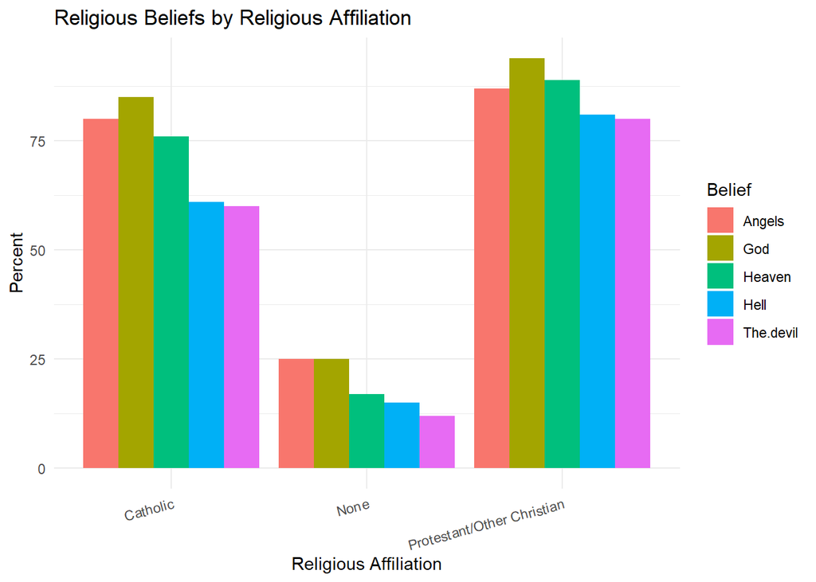

```r
# Visualization 3: Religion
religion <- data %>%
  filter(Category %in% c(
    "Protestant/Other Christian",
    "Catholic",
    "None"
  ))

religion_long <- religion %>%
  pivot_longer(
    cols = all_of(belief_cols),
    names_to = "Belief",
    values_to = "Percent"
  )

ggplot(religion_long,
       aes(x = Category,
           y = Percent,
           fill = Belief)) +
  geom_bar(stat = "identity",
           position = "dodge") +
  labs(
    title = "Religious Beliefs by Religious Affiliation",
    x = "Religious Affiliation",
    y = "Percent"
  ) +
  theme_minimal() +
  theme(
    axis.text.x = element_text(angle = 15, hjust = 1)
)
```

This one is a shocker for me but not many catholics are in the US in the east cost, rather towards the west cost and texas holds the majority of catholics in the US but this data collection came from the north. Not shockigly though is those who do not associate with any religions seldomly believe in anynof the 5 but some still do which that much is interesting, and Protestants fully believing as a great majority in these makes sense.

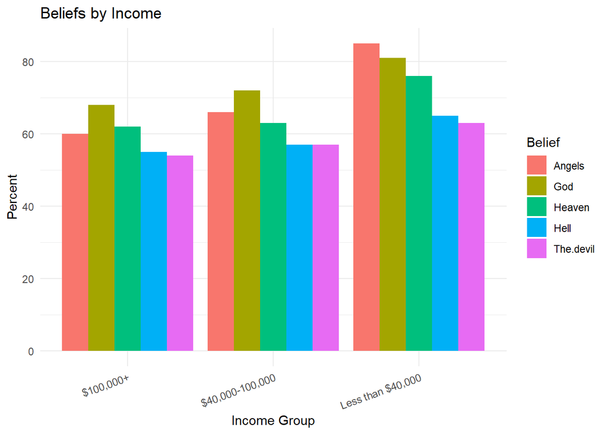

```r
# Visualization 4:Income

income <- data %>%
  filter(Category %in% c(
    "Less than $40,000",
    "$40,000-100,000",
    "$100,000+"
  ))

income_long <- income %>%
  pivot_longer(
    cols = all_of(belief_cols),
    names_to = "Belief",
    values_to = "Percent"
  )

ggplot(income_long,
       aes(x = Category,
           y = Percent,
           fill = Belief)) +
  geom_bar(stat = "identity",
           position = "dodge") +
  labs(
    title = "Beliefs by Income",
    x = "Income Group",
    y = "Percent"
  ) +
  theme_minimal() +
  theme(axis.text.x = element_text(angle = 20, hjust = 1))
```

Now this has some logic to it, the more money you make the less likely you are to care about religion and the data supports this idea, the less money you make the more likely you are to hold these religious beliefs, but still the majority does believe across all income brackets which is somewhat of a shocker to me.

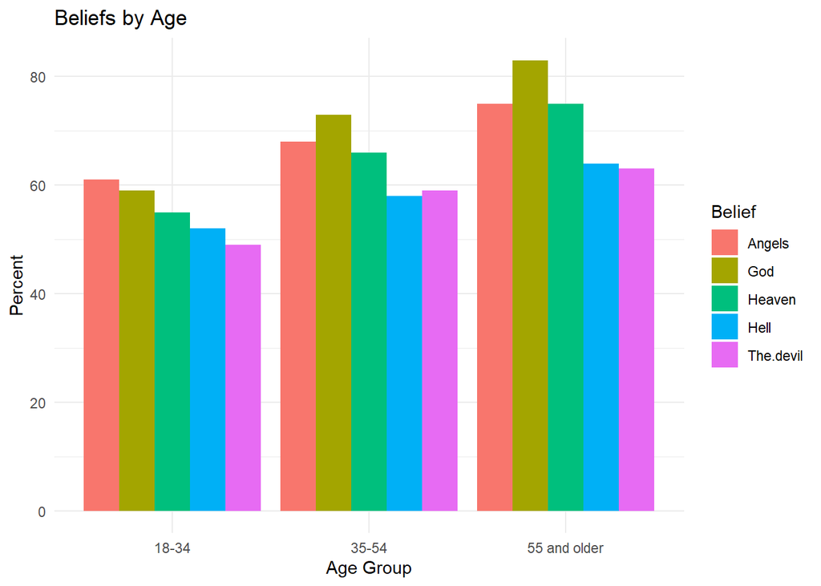

```r
# Visualization 5:Age


age <- data %>%
  filter(Category %in% c(
    "18-34",
    "35-54",
    "55 and older"
  ))

age_long <- age %>%
  pivot_longer(
    cols = all_of(belief_cols),
    names_to = "Belief",
    values_to = "Percent"
  )

ggplot(age_long,
       aes(x = Category,
           y = Percent,
           fill = Belief)) +
  geom_bar(stat = "identity",
           position = "dodge") +
  labs(
    title = "Beliefs by Age",
    x = "Age Group",
    y = "Percent"
  ) +
  theme_minimal()
```

This one has been changing recently this year, but since the data is from 2024 that wouldnt show but many people around my current age (23) are converting to a religion mainly catholicism in the United States, but still the majority of believers would fall in the 55 and older category as most younger people usually either dont care much at such as young age or plain dislike religous beliefs, and later in life in their 30’s is when usually people start to have a more religous life and settle in by their late 50’s and the data backs this up.

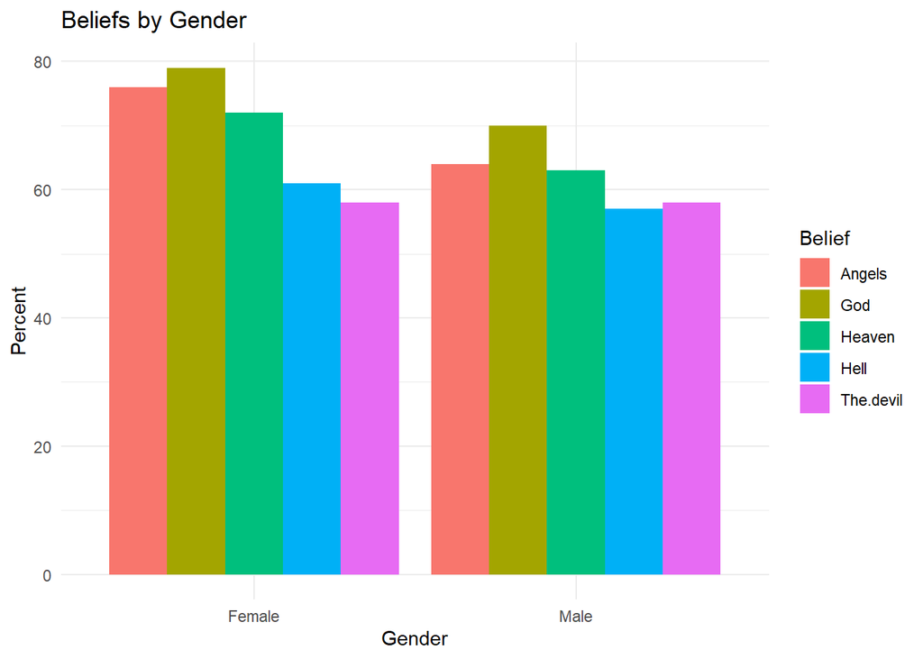

```r
# Visualization 6:Gender

gender <- data %>%
  filter(Category %in% c(
    "Male",
    "Female"
  ))

gender_long <- gender %>%
  pivot_longer(
    cols = all_of(belief_cols),
    names_to = "Belief",
    values_to = "Percent"
  )

ggplot(gender_long,
       aes(x = Category,
           y = Percent,
           fill = Belief)) +
  geom_bar(stat = "identity",
           position = "dodge") +
  labs(
    title = "Beliefs by Gender",
    x = "Gender",
    y = "Percent"
  ) +
  theme_minimal()
```

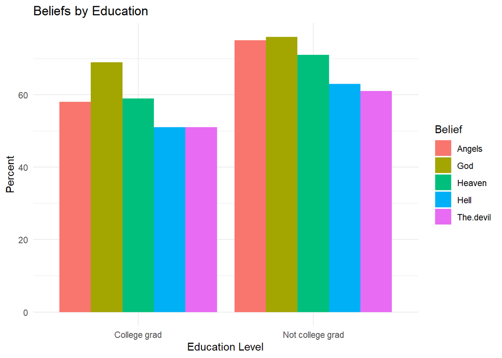

```r
# Visualization 7:Education


education <- data %>%
  filter(Category %in% c(
    "College grad",
    "Not college grad"
  ))

education_long <- education %>%
  pivot_longer(
    cols = all_of(belief_cols),
    names_to = "Belief",
    values_to = "Percent"
  )

ggplot(education_long,
       aes(x = Category,
           y = Percent,
           fill = Belief)) +
  geom_bar(stat = "identity",
           position = "dodge") +
  labs(
    title = "Beliefs by Education",
    x = "Education Level",
    y = "Percent"
  ) +
  theme_minimal()
```

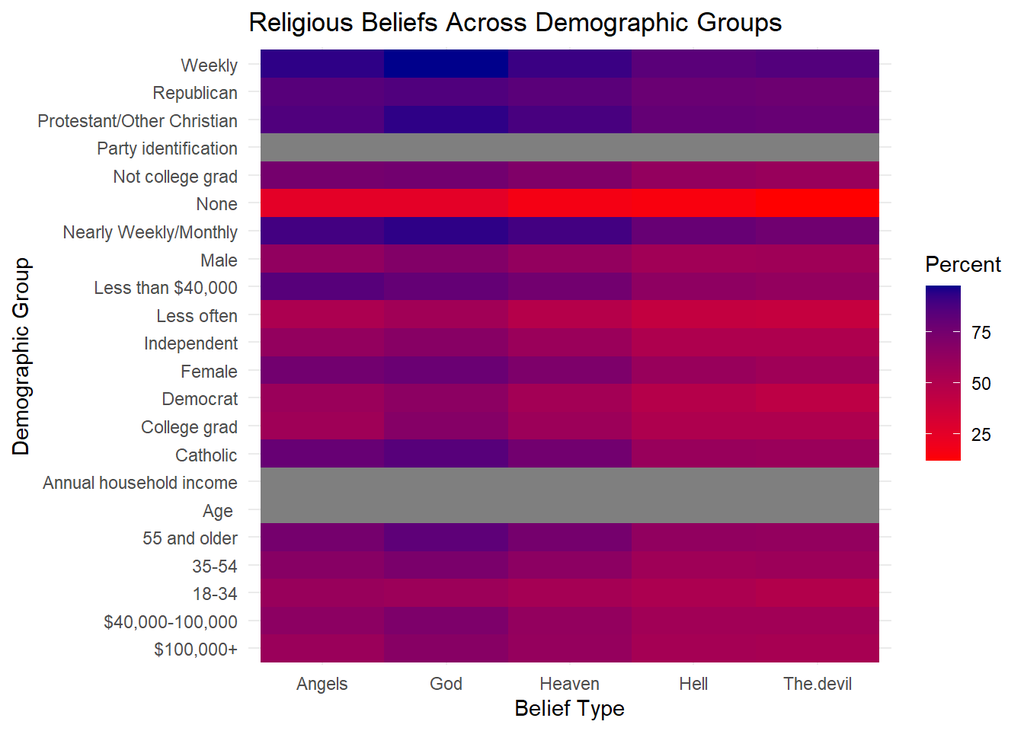

```r
# Visualization 8:Heatmap (All Groups)

heat_data <- data %>%
  pivot_longer(
    cols = all_of(belief_cols),
    names_to = "Belief",
    values_to = "Percent"
  )

ggplot(heat_data,
       aes(x = Belief,
           y = Category,
           fill = Percent)) +
  geom_tile() +
  scale_fill_gradient(
    low = "red",
    high = "darkblue"
  ) +
  labs(
    title = "Religious Beliefs Across Demographic Groups",
    x = "Belief Type",
    y = "Demographic Group"
  ) +
  theme_minimal()
```

Here we can get a better comparisson to each category one next to the other, here we can really tell that those that do not believe in any religion really are less likely to believe anything meanwhile overall there is a great variance between age groups, attendance, college grads and household income. (the grey parts are headers which i could not get rid of not matter what I did, I tried asking chatgpt for help here but even if I got rid of those specific headers, new ones would come out grey, and I am not sure why, so I left this original one as it seemed better than others.)

#Process and answers: I had to find the data on Kaggle (https://www.kaggle.com/datasets/patricklford/americans-belief-in-spiritual-concepts?resource=download), and then I had to clean up the excel file by getting rid of the empty cells and tidying it up so the data would not look confusing. I wanted to find a data set in which i could have scatter plots about olympic game medals but it turned to be a bust as I could not find good data to work with, then I found this dataset looking for catholic datasets. The story that can be told here is that the older you are, the more right wing you are, if you have not graduated college, you don’t make much money, and you are a devout believer that attends religious service you are more likely to believe in God, Heaven, Angels, Hell and the devil. Which overall makes sense to me. I applied data visualization principles in this mini project by clearing the data, piping and separating each section properly and bringing it all together to make a more clear comparrison.